# JAX Gaussian Mixture Model (EM) Demo

This notebook demonstrates the usage of my from-scratch implementation of the Expectation Maximization algorithm for Gaussian Mixture Models.

Repo - https://github.com/loshmii/gmm

## Environment

We install dependencies, import the library and inspect the backend.

```python
!pip install -r requirements.txt
```

```python
import jax
import jax.numpy as jnp
from gmm import GaussianMixture

import matplotlib.pyplot as plt
from sklearn.datasets import make_blobs, make_classification
from sklearn.mixture import GaussianMixture as SkGMM
```

```python
print('JAX version:', jax.__version__)
print('JAX backend:', jax.default_backend())
print('Available devices:', jax.devices())
```

```
JAX version: 0.8.0
JAX backend: cpu
Available devices: [CpuDevice(id=0)]
```

## Problem setting

### Model definition

Given a dataset $\{y_n\}_{n=1}^N$ of $D$-dimensional vectors, we assume a latent variable $z_n \in \{1, \ldots, K\}$ for each $y_n$ representing its origin cluster.  
The generative model is defined as:

- $z_n \sim \text{Categorical}(\pi_1, \ldots, \pi_K)$
- $y_n \mid z_n = k \sim \mathcal{N}(\mu_k, \Sigma_k)$

### Expectation (E) step

In the E-step, we compute the posterior distribution of the latent variables given the data and the current parameters. We denote the posterior probability of $z_n = k$ at the time step $t$ as $\gamma^{(t)}_{nk}$ as in the literature.

$$ \gamma^{(t)}_{nk} = p(z_n = k \mid y_n; \theta^{(t)}) = \frac{\pi^{(t)}_k \, \mathcal{N}\!\left(y_n \mid \mu^{(t)}_k, \Sigma^{(t)}_k\right)} {\sum_{k'=1}^{K} \pi^{(t)}_{k'} \, \mathcal{N}\!\left(y_n \mid \mu^{(t)}_{k'}, \Sigma^{(t)}_{k'}\right)} $$

where $\mathcal{N}(y_n \mid \mu^{(t)}_k, \Sigma^{(t)}_k)$ is the Gaussian density with mean $\mu^{(t)}_k$ and covariance $\Sigma^{(t)}_k$, and $\pi^{(t)}_k$ is the mixing coefficient for cluster $k$ at iteration $t$.

### Maximization (M) step

In the M-step, we maximize the expected log-likelihood with respect to the parameters $\theta$ using the posterior probabilities computed in the E-step:

$$ \mathcal{l}^{(t)}(\theta) = \sum_{n} \sum_{z_n} q^{(t)}_{n}(z_n)\, \log \frac{p(y_n, z_n \mid \theta)}{q^{(t)}_{n}(z_n)} $$

expressed as optimization objective this becomes:

$$ \text{maximize} \sum_{n}\sum_{k} \gamma^{(t)}_{nk}\,\log \pi_k \;-\; \frac{1}{2} \sum_{n}\sum_{k} \gamma^{(t)}_{nk} \Big[ (y_n - \mu_k)^\top \Sigma_k^{-1} (y_n - \mu_k) + \log|\Sigma_k| \Big] $$

$$ \text{s.t.} \sum_{k} \pi_k = 1$$

Using Lagrange multipliers we get the update rules:

$$ \pi^{(t+1)}_k = \frac{\sum_{n} \gamma^{(t)}_{nk}}{N}, \qquad k = 1, \ldots, K. $$

$$ \mu^{(t+1)}_k = \frac{\sum_{n} \gamma^{(t)}_{nk}\, y_n} {\sum_{n} \gamma^{(t)}_{nk}}, \qquad k = 1, \ldots, K. $$

$$ \Sigma^{(t+1)}_k = \frac{ \sum_{n} \gamma^{(t)}_{nk}\, \bigl( y_n - \mu^{(t+1)}_k \bigr) \bigl( y_n - \mu^{(t+1)}_k \bigr)^\top }{ \sum_{n} \gamma^{(t)}_{nk} }, \qquad k = 1, \ldots, K. $$

## Small example

In the following example we illustrate core idea of the library: data $\to$ fit $\to$ plot $\to$ inspect loss.

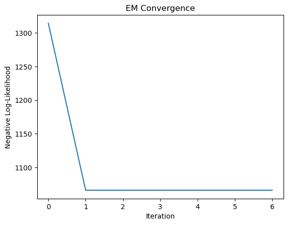

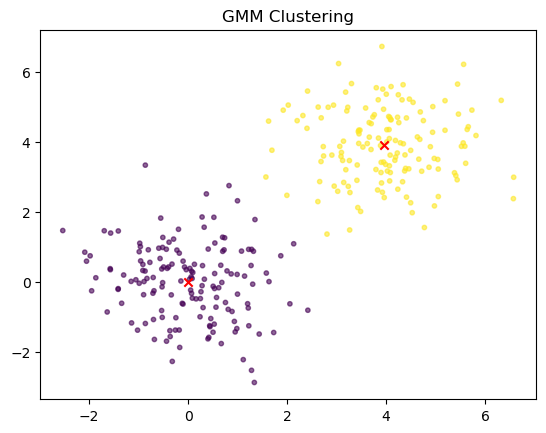

```
Final NLL: 1066.2991463803596
```

```python
key = jax.random.key(0)

true_means = jnp.array([[0.,0.], [4.,4.]])
n_samples = 300

# sample indices
comp_idx = jax.random.randint(key, (n_samples,), minval=0, maxval=2)
X = jax.random.normal(key, (n_samples, 2)) + true_means[comp_idx]

model = GaussianMixture(n_components=2, rng_key=key).fit(X)

model.plot(iter_losses=True, cluster_scatter=True)
print('Final NLL:', model.loss_trace[-1])
```

As mathematically shown, the negative log-likelihood (NLL) (`loss_trace`) decreases in each time step until it converges, as it is bounded from above by the current iteration at each time step. We can observe that the algorithm converges relatively fast, and we notice two distinct data clusters around the specified means.

## $\mathbb{R}^2$ demo with ground-truth parameters

In the following example we generate synthetic 2D samples with non-spherical covariance matrix. The goal is reconstruction of the ground-truth parameters.

```python
key = jax.random.key(42)

true_means = jnp.array([[0., 0.], [3., 1.], [-2., 3.]])
true_covs = jnp.array([
    [[0.5, 0.2],
     [0.2, 0.8]],
    [[0.8,-0.3],
     [-0.3,0.5]],
    [[0.3, 0.0],
     [0.0, 0.3]],
])
```

```python
n_components, dim = true_means.shape
n_per_comp = 300

Xs = []
for k in range(n_components):
    subkey = jax.random.fold_in(key, k)
    L = jnp.linalg.cholesky(true_covs[k])
    z = jax.random.normal(subkey, (n_per_comp, dim))
    Xk = true_means[k] + z @ L.T
    Xs.append(Xk)

X = jnp.concatenate(Xs, axis=0)
```

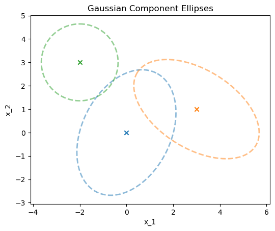

```python
from plotting_utils import plot_cov_ellipse

fig, ax = plt.subplots()
K = n_components

for k in range(K):
    mean_k = jnp.array(true_means[k])
    cov_k = jnp.array(true_covs[k])
    plot_cov_ellipse(
        mean_k, cov_k, ax=ax,
        n_std = 3.0, linestyle='--',
        linewidth=2, alpha=0.5
    )
    ax.scatter(mean_k[0], mean_k[1], marker='x')

ax.set_xlabel('x_1')
ax.set_ylabel('x_2')
ax.set_title('Gaussian Component Ellipses')
ax.set_aspect('equal', adjustable='box')
plt.show()
```

```python
model = GaussianMixture(n_components=n_components, rng_key=key).fit(X)
```

```python
print("True means:\n", true_means)
print("Learned means:\n", model.means)

mean_error = jnp.linalg.norm(jnp.sort(model.means, axis=0)-jnp.sort(true_means, axis=0))
print("Mean parameter error (normed):\n", float(mean_error))
```

```
True means:
 [[ 0.  0.]
 [ 3.  1.]
 [-2.  3.]]
Learned means:
 [[ 1.48420526  0.46405323]
 [-1.71761273  2.88573747]
 [-2.36549338  3.14947309]]
Mean parameter error (normed):
 3.0290437471296574
```

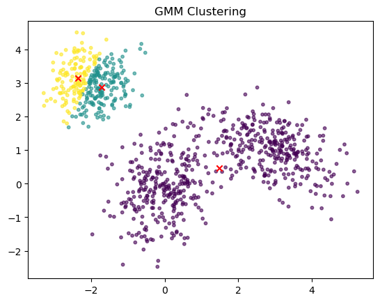

```python
model.plot(iter_losses=False, cluster_scatter=True)
```

The above example illustrates one common **pitfall** of the EM algorithm for GMMs. Namely, as the optimization problem is not convex, algorithm can terminate inside $\emph{locally}$ optimal region, and fail to reconstruct the ground-truth parameters. The model combines two clusters into one, and splits one cluster into two.

#### Mitigation

In the following section we will try to mitigate the problem using multi-seed initialization. We will select the model with the best log-likelihood.

```python
best_model = None
best_ll = -jnp.inf

for seed in range(5):
    m = GaussianMixture(n_components=3, rng_key=jax.random.key(seed)).fit(X)
    ll = m.score_samples(X).mean()
    if ll > best_ll:
        best_ll, best_model = ll, m
```

```python
print("True means:\n", true_means)
print("Learned means:\n", best_model.means)

mean_error = jnp.linalg.norm(jnp.sort(best_model.means, axis=0)-jnp.sort(true_means, axis=0))
print("Mean parameter error (normed):\n", float(mean_error))
```

```
True means:
 [[ 0.  0.]
 [ 3.  1.]
 [-2.  3.]]
Learned means:
 [[ 2.94306285  1.02332284]
 [-2.00064219  2.99971113]
 [-0.03453412 -0.12072688]]
Mean parameter error (normed):
 0.13983516643148647
```

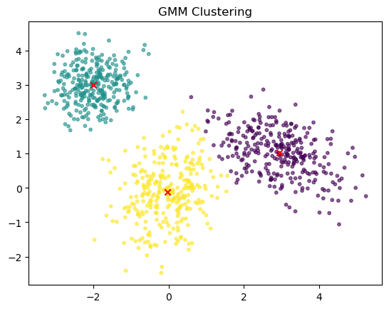

```python
best_model.plot(iter_losses=False, cluster_scatter=True)
```

We can see that the model manages to reconstruct the optimal hyperparameters with the selection technique.

### Responsibilities and soft clustering

The responsibilities:

$$ \Gamma = \bigl[ \gamma_{nk} \bigr]_{n=1,\dots,N}^{k=1,\dots,K} \qquad \text{where} \qquad \gamma_{nk} = p(z_n = k \mid x_n) $$

can be computed using `predict_proba` API. We wish now to visualize samples on which the model is uncertain. The ucertainty information can be used in outlier detection, and in active-learning-y algorithms.

```python
R = best_model.predict_proba(X)
print("Responsibilities shape:", R.shape)

row_sums = R.sum(axis=1)
print("Mean row sum (should be 1):", float(row_sums.mean()))
```

```
Responsibilities shape: (900, 3)
Mean row sum (should be 1): 1.0
```

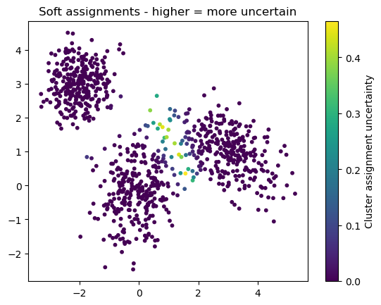

```python
uncertainty = 1.0 - R.max(axis=1)

fig, ax = plt.subplots()
sc = ax.scatter(X[:, 0], X[:, 1], c = uncertainty, s = 10)
plt.colorbar(sc, ax=ax, label='Cluster assignment uncertainty')
ax.set_title('Soft assignments - higher = more uncertain')
plt.show()
```

As expected we can see that the model uncertainty increases at the boundary between the two relatively close clusters.

### API tour on a tabular dataset

```python
X_tab, y_tab = make_blobs(n_samples=2000,
    n_features=6,
    random_state=0)

X_tab = jnp.array(X_tab)

model_tab = GaussianMixture(n_components=3, rng_key=jax.random.key(123)).fit(X_tab)

cluster_labels = model_tab.predict(X_tab)
log_probs = model_tab.score_samples(X_tab)

print("Cluster labels shape:", cluster_labels.shape)
print("Log-likelihoods shape:", log_probs.shape)
```

```
Cluster labels shape: (2000,)
Log-likelihoods shape: (2000,)
```

The model can be used as only a part of a greater classification/clustering pipeline. For example, we could feed the model sample features after they have been mapped to lower-dimensional space using techniques like `PCA` or `t-SNE`.

### Comparison to scikit-learn's GaussianMixture

```python
import time
import numpy as np

X_np = np.asarray(X_tab)

def fit_jax_once(seed):
    key = jax.random.key(seed)
    t0 = time.time()
    model = GaussianMixture(n_components=3, rng_key=key).fit(jnp.asarray(X_tab))
    ll_mean = model.score_samples(X_tab).mean()
    jax.block_until_ready(ll_mean)
    t1 = time.time()
    return float(ll_mean), t1-t0

def fit_sk_once(seed):
    t0 = time.time()
    model = SkGMM(n_components=3, covariance_type='full', random_state=seed)
    model.fit(X_np)
    ll_mean = model.score_samples(X_np).mean()
    t1 = time.time()
    return float(ll_mean), t1 - t0

n_restarts = 50

jax_lls, jax_times = [], []
sk_lls, sk_times = [], []

for seed in range(n_restarts):
    ll_j, t_j = fit_jax_once(seed)
    ll_s, t_s = fit_sk_once(seed)
    jax_lls.append(ll_j); jax_times.append(t_j)
    sk_lls.append(ll_s); sk_times.append(t_s)

print("JAX best ll:", max(jax_lls), "mean time:", np.mean(jax_times[2:]))
print("sk best ll:", max(sk_lls), "mean time:", np.mean(sk_times))
print("Best ll difference:", max(jax_lls) - max(sk_lls))
```

```
JAX best ll: -9.53455629831816 mean time: 0.07273275156815846
sk best ll: -9.534556297977307 mean time: 0.007160067558288574
Best ll difference: -3.4085267941463826e-10
```

Over 50 random initializations, both our `JAX` EM implementation and `scikit-learn`'s `GaussianMixture` converge to the same maximum log-likelihood (difference $3\times10^{-10}$), confirming that our implementation matches `sklearn`'s objective and optimisation behaviour up to numerical precision.